# Pulling SODA Bottom Temp Data

- This project is a collaborative effort to describe changes in taxonomic composition of fish communities around the world–as sampled by bottom trawl surveys.
- Code by Zoë J. Kitchel

SBT Temperature 1980-2019 = SODA 3.3.2

Unique Lat Lon for each Survey/season.

```r
unique_lat_lon <- unique(FishGlob_clean[,.(latitude, longitude, survey_unit)])

#data range for SODA data is (0,360), so I will edit lat lon to match
unique_lat_lon[,longitude.shift := ifelse(longitude >= 0, longitude, 360+longitude)]

summary(unique_lat_lon[,longitude.shift])
```

```
   Min. 1st Qu.  Median    Mean 3rd Qu.    Max.
   0.00   19.17  264.57  202.70  298.64  360.00
```

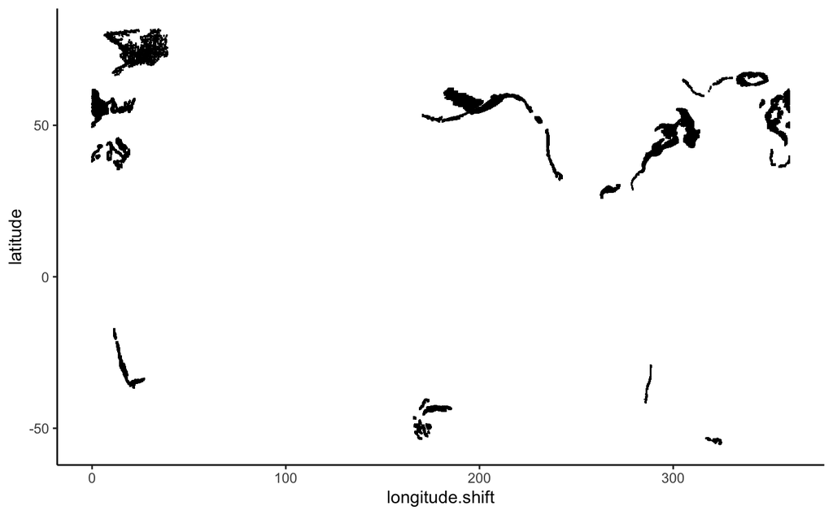

```r
#check to make sure shift makes sense
shift_check <- ggplot(unique_lat_lon, aes(x = longitude.shift, y = latitude)) +
  geom_point(shape = ".") +
  theme_classic()


shift_check2 <- ggplot(unique_lat_lon, aes(x = longitude, y = latitude)) +
  geom_point(shape = ".") +
  theme_classic()

shift_check
```

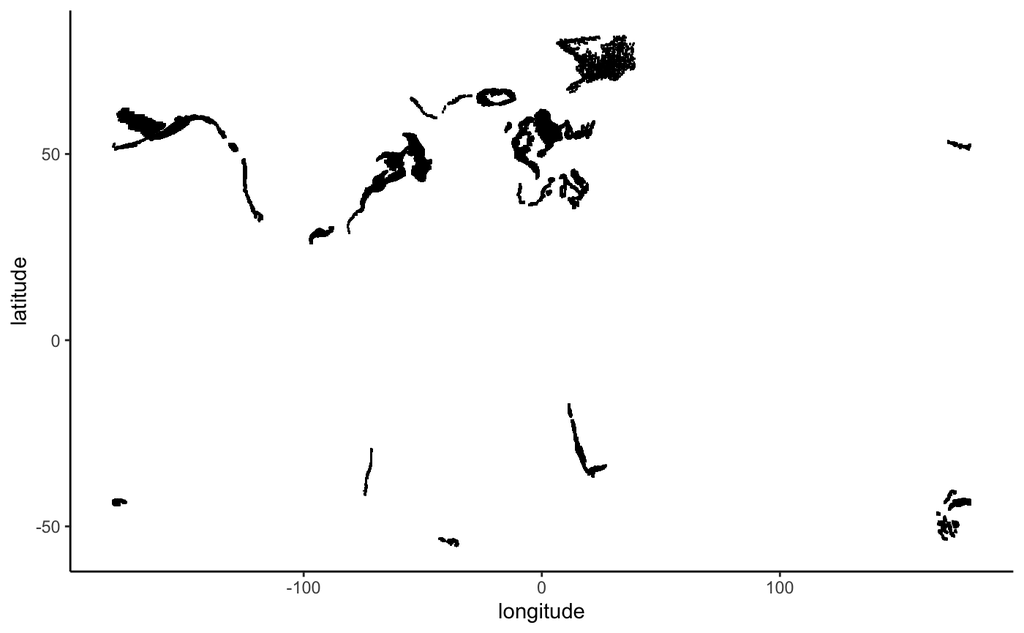

```r
shift_check2
```

###Pull all date values for each Lat Lon from SODA raster (soda_bottom_jan_2023.grd)

```r
extract(s,unique_lat_lon[,.(longitude.shift, latitude)])
```

```
Error in extract(s, unique_lat_lon[, .(longitude.shift, latitude)]) :
  could not find function "extract"
```

Wide to Long to make calculations (Note, some temp values from unique_lat_lon.temp.l are NA, but only 1% so shouldn’t make any difference)

Delete X from Date column

```r
unique_lat_lon.temp.l[, date.formatted := lubridate::ymd(substr(date,2,nchar(as.character(date))))]

unique_lat_lon.temp.l[, year := lubridate::year(date.formatted)][, month := lubridate::month(date.formatted)][, day := lubridate::day(date.formatted)]
```

###Average Values

First go from daily temp to average monthly temp. We need temp 12 months before haul date. We’ll take yearly: * mean * max * min * seas * SD of mean * SD of max * SD of min * SD of seas

And now all other regions

```r
#to maximize memory, remove FishGlob_clean except for min_month
FishGlob_clean.months_surveys <- unique(FishGlob_clean[,.(survey_unit, month)])
FishGlob_clean.months_surveys[survey_unit == "MEDITS", month := 4]
FishGlob_clean.months_surveys[survey_unit == "GRL-DE", month := 8] #NEED TO CHECK THIS

rm(FishGlob_clean)

SODA_data_temp_avgs_full <- data.table()

for (i in 1:length(all_survey_units)) {
  min_month <- min(FishGlob_clean.months_surveys[survey_unit == all_survey_units[i]]$month)

  #pull in data from rds files if not already in console


  unique_lat_lon.temp.l[,month := month(t)][,year := year(t)]

#set year for taking temp measurements (12 months before first haul for that survey unit)

  unique_lat_lon.temp.l[, year_for_avg := ifelse(month >= min_month, year+1, year)]

  #next two steps take a lot of time

#take mean, min, max, and seas of each lat long point for each year
  unique_lat_lon.temp.l[, yearly_mean_bypoint := mean(temp), .(year_for_avg, lat, lon)][,
              yearly_max_bypoint := max(temp), .(year_for_avg, lat, lon)][,                                                                yearly_min_bypoint := min(temp), .(year_for_avg, lat, lon)][,
              yearly_seas_bypoint := yearly_max_bypoint-yearly_min_bypoint]

  #cuts down size of object from hundreds of millions to
  SODA_data <- unique(unique_lat_lon.temp.l[,.(yearly_mean_bypoint, yearly_max_bypoint, yearly_min_bypoint, yearly_seas_bypoint, lat, lon, year_for_avg)])

#next, we want yearly avg of mean, min, max, and seas
    unique_lat_lon.temp.l[, yearly_mean_bypoint_avg := mean(yearly_mean_bypoint), .(year_for_avg)][,
              yearly_max_bypoint_avg := mean(yearly_max_bypoint), .(year_for_avg)][,                                                       yearly_min_bypoint_avg := mean(yearly_min_bypoint), .(year_for_avg)][,
              yearly_seas_bypoint_avg := mean(yearly_seas_bypoint), .(year_for_avg)]

  #next, to calculate SD of mean, take mean of each cell in each year, and then calculate the SD of the means
  #to calculate SD of max, take max of each cell in each year, and then calculate the SD of the maxes, etc.
    unique_lat_lon.temp.l[, yearly_mean_bypoint_SD := sd(yearly_mean_bypoint), .(year_for_avg)][,
              yearly_max_bypoint_SD := sd(yearly_max_bypoint), .(year_for_avg)][,                                                       yearly_min_bypoint_SD := sd(yearly_min_bypoint), .(year_for_avg)][,
              yearly_seas_bypoint_SD := sd(yearly_seas_bypoint), .(year_for_avg)]


  #finally, scaled versions by region
#next, we want yearly avg of mean, min, max, and seas
    unique_lat_lon.temp.l[, yearly_mean_bypoint_avg.s := scale(yearly_mean_bypoint_avg)][,
                 yearly_max_bypoint_avg.s := scale(yearly_max_bypoint_avg)][,                                                                        yearly_min_bypoint_avg.s := scale(yearly_min_bypoint_avg)][,
                 yearly_seas_bypoint_avg.s := scale(yearly_seas_bypoint_avg)]

  #to calculate SD of max, take max of each cell in each year, and then calculate the SD of the maxes, etc.
    unique_lat_lon.temp.l[, yearly_mean_bypoint_SD.s := scale(yearly_mean_bypoint_SD)][,
              yearly_max_bypoint_SD.s := scale(yearly_max_bypoint_SD)][,                                                                           yearly_min_bypoint_SD.s := scale(yearly_min_bypoint_SD)][,
              yearly_seas_bypoint_SD.s := scale(yearly_seas_bypoint_SD)]

#uniquevalues
    SODA_data_temp_avgs <- unique(unique_lat_lon.temp.l[, .(year_for_avg, yearly_mean_bypoint_avg, yearly_max_bypoint_avg, yearly_min_bypoint_avg, yearly_seas_bypoint_avg, yearly_mean_bypoint_SD, yearly_max_bypoint_SD, yearly_min_bypoint_SD, yearly_seas_bypoint_SD, yearly_mean_bypoint_avg.s, yearly_max_bypoint_avg.s, yearly_min_bypoint_avg.s, yearly_seas_bypoint_avg.s, yearly_mean_bypoint_SD.s, yearly_max_bypoint_SD.s, yearly_min_bypoint_SD.s, yearly_seas_bypoint_SD.s)])

  SODA_data_temp_avgs[, survey_unit := all_survey_units[i]]

  SODA_data_temp_avgs_full <- rbind(SODA_data_temp_avgs_full, SODA_data_temp_avgs)


  print(all_survey_units[[i]]) #to help keep track


}


#save summary table!!!
saveRDS(SODA_data_temp_avgs_full, here::here("data","Temperature","SODA_data_temp_avgs_full.rds"))

#annotate (if working on HPC)
saveRDS(SODA_data_temp_avgs_full, here::here("SODA_data_temp_avgs_full.rds"))
```